# Meta-analysis of within-subject variability in published bioequivalence studies

INTERIM read-out — data extraction in progress

Jerry Hu

2026-06-02

← PK/PD Home Page

**INTERIM read-out — data extraction in progress.**

**Interim status (2026-06-02).** This is a *preliminary* read-out built while data extraction is still being conducted. Currently, the pooled estimates below consist of **15 studies**. The target is **100–200 studies**. After data extraction is complete, the datasets will be examined. Based on what data is available, the research objectives will be specified. In the meantime, descriptive statistics of the available data are reported below.

# 1 Background & objective

A bioequivalence (BE) study is powered on a **CV<sub>w</sub> assumed in advance** — guessed from a pilot, a prior study, or the literature. The within-subject CV drives the sample size of a 2×2 crossover directly: too low an assumption and the study is under-powered; too high and it is wastefully large. Once the study reads out, the *realized* CV<sub>w</sub> is whatever the data deliver.

**Question.** Across the published BE record, how does the **assumed** CV<sub>w</sub> compare to the **realized** CV<sub>w</sub>, and how does that gap move the BE outcome — the geometric mean ratio (GMR) point estimate, the 90% CI width, and realized vs planned power? Because absolute CV<sub>w</sub> is drug-specific, the poolable quantity is the **dimensionless observed/assumed ratio** $r = \mathrm{CV_w^{obs}} / \mathrm{CV_w^{assumed}}$.

# 2 Methods

## 2.1 Data sources & literature search

Data are collected from the **published bioequivalence record** by a PRISMA-aligned systematic search, framed as an **open search-term census** over the modern reporting era (2010–present) and run to exhaustion: a fixed Boolean query is applied across the searchable corpora and *every eligible record is included* (no convenience cut; a pre-specified random sample, seed `20260601`, is the only down-selection if the eligible pool ever exceeds extraction capacity).

## 2.2 Per-study extraction

We extract, per study, the reported design (n, α, planned GMR, target power), the planning CV<sub>w</sub> where stated, and the realized 90% CI of the GMR for each PK metric (Cmax, AUC0-t, AUC0-inf). From these we recover three quantities.

## 2.3 Realized CV<sub>w</sub> — back-calculated from n and the 90% CI

For a 2×2 crossover, the realized within-subject variance is recovered from the log-scale 90% CI half-width $H$ of the GMR on $n$ completers:

$$\mathrm{SE} = \frac{H}{t_{0.95,\,n-2}},
\qquad \mathrm{MSE} = \mathrm{SE}^2 \cdot \frac{n}{2}, \qquad
\mathrm{CV_w^{obs}} = \sqrt{e^{\mathrm{MSE}} - 1}$$

where $H$ is the half-width of the CI on the log ratio, $t_{0.95,\,n-2}$ the upper 5% Student-$t$ quantile on $n-2$ degrees of freedom, $\mathrm{SE}$ the standard error of the treatment difference on the log scale, and $\mathrm{MSE}$ the residual (within-subject) mean square. This back-calculation is validated against the subset of studies that report the ANOVA CV<sub>w</sub> directly (agreement reported in the full read-out).

## 2.4 Assumed CV<sub>w</sub> — stated, or inverted from the chosen n

Where the sample-size justification states the planning CV<sub>w</sub>, it is used directly. Otherwise it is **recovered by inverting** the 2×2 sample-size relation for the CV<sub>w</sub> that makes the chosen $n$ exactly adequate under the study’s stated GMR, α, and target power:

$$n \;=\;
\text{ssize}_{2\times2}\!\left(\mathrm{CV_w^{assumed}},\,
\mathrm{GMR},\, \alpha,\, 1-\beta\right) \;\;\Longrightarrow\;\;
\mathrm{CV_w^{assumed}} = \text{solve for the CV at the chosen } n$$

the inversion uses the conventional two one-sided-tests (TOST) sample-size function (`PowerTOST`); the recovered value is validated on studies that state the planning CV explicitly. *This interim read-out pools only the directly-stated planning CVs; the inverted set is validated but not yet folded into the headline.*

## 2.5 Planning gap and its consequence

$$r =
\frac{\mathrm{CV_w^{obs}}}{\mathrm{CV_w^{assumed}}}, \qquad
\text{realized power} = \text{power}_\text{TOST}\!\left(\mathrm{CV} =
\mathrm{CV_w^{obs}},\; n = n_\text{total},\; \mathrm{GMR},\;
\alpha\right)$$

$r > 1$ means the study realized *more* variability than it planned for (under-planned, power eroded); $r < 1$ means it planned conservatively. Realized power re-evaluates the TOST power at the CV the data actually delivered, holding n and the planned GMR fixed.

# 3 Results

## 3.1 Before vs after: assumed vs realized CV<sub>w</sub>

Each row is one study-metric: the grey dot is the **assumed** (planning) CV<sub>w</sub>, the coloured dot the **realized** CV<sub>w</sub>; red marks studies where the realized CV exceeded what was planned for.

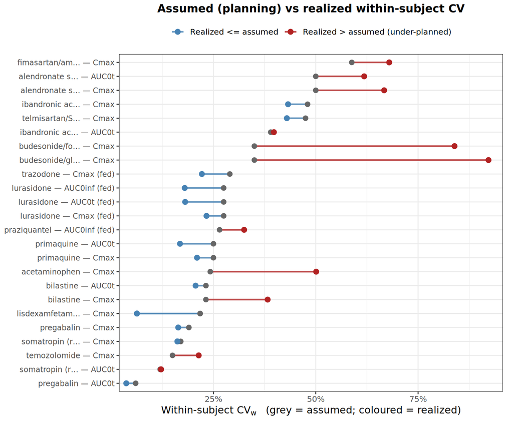

The ratio collapses this to one dimensionless number per comparison:

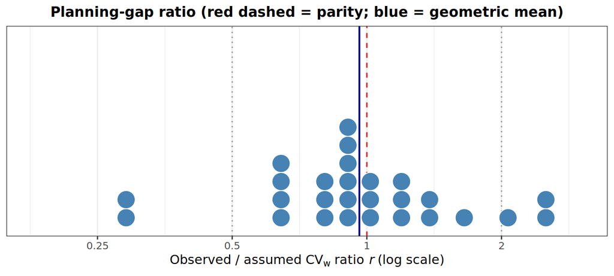

- **Central tendency**: the geometric-mean ratio is **0.962** (IQR 0.803–1.23), i.e. planning CV<sub>w</sub> is on average close to realized — but the spread is wide (range 0.29–2.63).
- **Direction**: in **44.4%** of comparisons the realized CV<sub>w</sub> *exceeded* the assumed value — the under-planned tail that erodes power.

## 3.2 Headline point estimates

Interim point estimates — planning vs realized.

| Quantity | Estimate |
| --- | --- |
| Assumed CV_w (planning) | 0.25 (median) |
| Observed CV_w (realized) | 0.214 (median) |
| Observed / assumed CV_w ratio (geometric mean) | 0.962 [IQR 0.803-1.23; range 0.29-2.63] |
| Share of studies with realized CV_w > assumed | 44.4% |
| Planned GMR (sample-size assumption) | 1.1 ( 110%) |
| Realized GMR (median) | 1.01 ( 101%) |
| Planned power | 0.825 (82.5%) |
| Realized power (median) | 0.96 ( 96%) |
| Share realized-underpowered (<80%) | 37% |
| BE pass rate | 85.2% |

Note: Interim: 15 studies / 27 PK-metric comparisons of 108 papers extracted. Descriptive pooling (geometric mean), not inverse-variance weighted.

The **planned GMR is 1.1 ( 110%)** — the canonical sample-size assumption — against a **realized GMR of 1.01 ( 101%)** at the median. Although the median realized power ( 96%) sits above target, **37%** of comparisons fall below 80% once re-evaluated at the realized CV<sub>w</sub> — the practical cost of the planning gap.

## 3.3 Per-study detail

Analyzable studies (interim): assumed vs realized CV, ratio, GMR, realized power.

| Drug | Metric | n | Assumed CV | Observed CV | Ratio r | Planned GMR | Realized GMR | Realized power | Outcome |
| --- | --- | --- | --- | --- | --- | --- | --- | --- | --- |
| pregabalin | AUC0t | 39 | 0.06 | 0.037 | 0.612 | 1.11 | 1.02 | 1 | pass |
| somatropin (recombinant human growth hormone) | AUC0t | 28 | 0.12 | 0.122 | 1.02 | NA | 1.05 | 1 | pass |
| somatropin (recombinant human growth hormone) | AUC0t | 28 | 0.12 | 0.122 | 1.02 | NA | 0.991 | 1 | pass |
| temozolomide | Cmax | 16 | 0.15 | 0.214 | 1.43 | NA | 0.944 | 0.67 | pass |
| somatropin (recombinant human growth hormone) | Cmax | 28 | 0.17 | 0.162 | 0.953 | NA | 0.954 | 0.988 | pass |
| somatropin (recombinant human growth hormone) | Cmax | 28 | 0.17 | 0.162 | 0.953 | NA | 0.955 | 0.988 | pass |
| pregabalin | Cmax | 39 | 0.19 | 0.164 | 0.864 | 1.11 | 0.993 | 0.935 | pass |
| lisdexamfetamine dimesylate | Cmax | 30 | 0.217 | 0.063 | 0.29 | 1.05 | 0.971 | 1 | pass |
| lisdexamfetamine dimesylate | Cmax | 30 | 0.217 | 0.063 | 0.29 | 1.05 | 0.97 | 1 | pass |
| bilastine | Cmax | 41 | 0.232 | 0.382 | 1.65 | 1.1 | 1.01 | 0.443 | pass |
| bilastine | AUC0t | 41 | 0.232 | 0.206 | 0.891 | 1.1 | 0.979 | 0.872 | pass |
| acetaminophen | Cmax | 27 | 0.242 | 0.501 | 2.07 | NA | 1.06 | 0.0853 | Cmax fail; AUC0t and AUC0inf pass |
| primaquine | Cmax | 47 | 0.25 | 0.21 | 0.842 | 1.05 | 1.04 | 0.991 | pass |
| primaquine | AUC0t | 47 | 0.25 | 0.168 | 0.675 | 1.05 | 1.06 | 1 | pass |
| praziquantel | AUC0inf | 30 | 0.265 | 0.325 | 1.23 | NA | 0.962 | 0.605 |  |
| lurasidone | Cmax | 56 | 0.275 | 0.233 | 0.848 | 1.1 | 1.01 | 0.896 | pass |
| lurasidone | AUC0t | 56 | 0.275 | 0.181 | 0.659 | 1.1 | 0.929 | 0.981 | pass |
| lurasidone | AUC0inf | 56 | 0.275 | 0.18 | 0.655 | 1.1 | 0.931 | 0.982 | pass |
| trazodone | Cmax | 39 | 0.29 | 0.222 | 0.765 | NA | 1.03 | 0.96 | pass |
| budesonide/glycopyrronium/formoterol fumarate dihydrate (BGF MDI) vs budesonide/formoterol fumarate dihydrate DPI (BUD/FORM) | Cmax | 64 | 0.35 | 0.922 | 2.63 | 1.05 | 1.02 | 0.0271 | fail |
| budesonide/formoterol fumarate dihydrate MDI (BFF MDI) vs budesonide/formoterol fumarate dihydrate DPI (BUD/FORM) | Cmax | 65 | 0.35 | 0.839 | 2.4 | 1.05 | 1.04 | 0.0793 | fail |
| ibandronic acid | AUC0t | 146 | 0.39 | 0.398 | 1.02 | NA | 1.01 | 0.985 | pass |
| telmisartan/S-amlodipine FDC (CKD-828) | Cmax | 43 | 0.475 | 0.429 | 0.904 | 0.9 | 0.851 | 0.344 | pass |
| ibandronic acid | Cmax | 146 | 0.48 | 0.432 | 0.901 | NA | 1.03 | 0.97 | pass |
| alendronate sodium | Cmax | 36 | 0.5 | 0.667 | 1.33 | NA | 1.08 | 0.0259 | pass |
| alendronate sodium | AUC0t | 36 | 0.5 | 0.618 | 1.24 | NA | 1 | 0.0545 | pass |
| fimasartan/amlodipine/rosuvastatin FDC | Cmax | 53 | 0.588 | 0.679 | 1.16 | 1.1 | 1.08 | 0.119 | pass |

# 4 Interim limitations

- **Small analyzable N.** Only studies that *state* a planning CV<sub>w</sub> enter the pooled estimate at this stage; assumed-CV recovery by inversion (which roughly triples the set) is validated but not yet folded into the headline. Estimates will shift.
- **Descriptive pooling.** No inverse-variance weighting or between-study heterogeneity model yet (deferred to `04-analyze`); each comparison counts equally.
- **Image-locked tables** and non-2×2 designs are excluded here; selection toward cleanly-reported studies is possible.
- **Method label provisional.** Whether the hierarchical “MBMA” layer materializes is a post-extraction decision; the slug may be renamed `ma-` before final publish.

# 5 Reproducibility

Pipeline (run in order): `01-search` → `02-extract` → `03-derive/normalize_derive.R` → `05-tlf/build_tlf.R` → this report. Seed `20260601`. Back-calculation and TOST power use `PowerTOST`. This interim read-out was built from 108 extracted papers as of 2026-06-02.